# Machine Learning Assignment - Coursera

Sashank S. Tamhane

November 12, 2016

**Synopsis:** Personal fitness devices such as Fitbit, Jawbone Up, etc are used commonly to collect information about an individuals physical activity. These devices do a good job of capturing the duration of the activities however they do not necessarily measure the quality of the workout. In this project accelerometers are placed on belt, forearm, arm, and dumbell of 6 participant. They were asked to perform barbell lifts correctly and incorrectly in 5 different ways. The five ways are exactly according to the specification (Class A), throwing the elbows to the front (Class B), lifting the dumbbell only halfway (Class C), lowering the dumbbell only halfway (Class D) and throwing the hips to the front (Class E). Only Class A corresponds to correct performance. The goal of this project is to predict the manner in which they did the exercise. More information is available at http://groupware.les.inf.puc-rio.br/har

**Overall Approach** The overall approach primarily comprises of the steps below.

- Acquiring Data and Cleaning the dataset
- Testing different algorithms
- Predicting the output on the testing dataset.

**Acquiring Data and Cleaning the dataset**

- Load the Data

```r
library(caret)
library(rattle)
library(rpart)
library(randomForest)
library(repmis)
# loading data from the csv file, replacing blanks and NA as NA while loading the file
testing <- read.csv("pml-testing.csv", na.strings = c("NA", ""))
training <- read.csv("pml-training.csv", na.strings = c("NA", ""))

# data cleaning, remove any rows that does not have data
training <- training[,colSums(is.na(training))==0]
testing <- testing[,colSums(is.na(testing))==0]
```

Training set has 19622 obs. of 160 variables Testing set has 20 obs. of 160 variables

```r
# remove first 7 variable as it has no effect on the prediction
trainData <- training[, -c(1:7)]
testData <- testing[, -c(1:7)]

# create a validation sample
set.seed(7826)
inTrain <- createDataPartition(trainData$classe, p = 0.7, list = FALSE)
train <- trainData[inTrain, ]
validation <- trainData[-inTrain, ]
```

**Testing different algorithms**

For K-fold validation, I was running out of memory by using the default value of k which is 10 hence reduced the k value to 5 to help take with the computation.

- Classification and Regression, Recursive Partitioning (rpart) Algorithm

```r
# use classification tree cross validation for generating model
train_control <-trainControl(method="cv", number=5)
model_cv <- train(classe~., data=train, method="rpart", trControl=train_control)

# print the output
print(model_cv)
```

```
## CART
##
## 13737 samples
##    52 predictor
##     5 classes: 'A', 'B', 'C', 'D', 'E'
##
## No pre-processing
## Resampling: Cross-Validated (5 fold)
## Summary of sample sizes: 10989, 10989, 10990, 10989, 10991
## Resampling results across tuning parameters:
##
##   cp          Accuracy   Kappa
##   0.03722917  0.5241363  0.38747937
##   0.05953955  0.4144185  0.20668249
##   0.11423050  0.3482486  0.09762497
##
## Accuracy was used to select the optimal model using  the largest value.
## The final value used for the model was cp = 0.03722917.
```

rpart algorithm plot

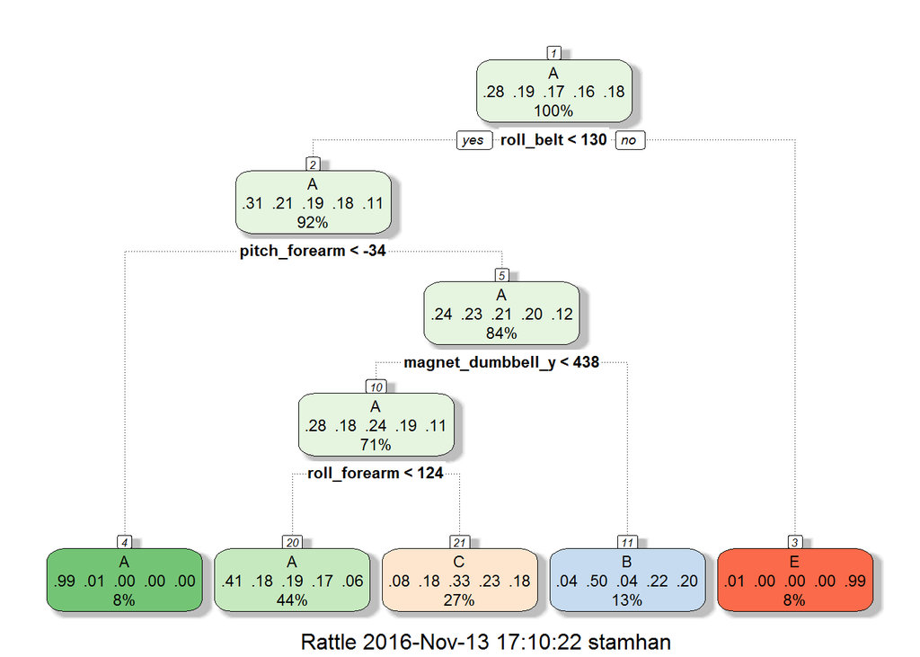

```r
# draw the plot for the model
fancyRpartPlot(model_cv$finalModel)
```

```r
# use the model for prediction
predict_test<- predict(model_cv, validation)

# use confusion matrix for measuring the accuracy
conf_mat<-confusionMatrix(validation$classe, predict_test)
print(conf_mat$overall[1])
```

```
##  Accuracy
## 0.5004248
```

- Random Forest

```r
## if we use random forest
model_rf<-train(classe~., data=train, method="rf", trControl=train_control)

# use the rf model for prediction
predict_rf<- predict(model_rf, validation)

# use confusion matrix for measuring the accuracy of rf
conf_mat_rf<-confusionMatrix(validation$classe, predict_rf)
print(conf_mat_rf$overall[1])
```

```
##  Accuracy
## 0.9940527
```

- Lda Model

```r
model_lda<-train(classe~., data=train, method="lda", trControl=train_control)
predict_lda<- predict(model_lda, validation)

# use confusion matrix for measuring the accuracy of lda
conf_mat_lda<-confusionMatrix(validation$classe, predict_lda)
print(conf_mat_lda$overall[1])
```

```
##  Accuracy
## 0.7039932
```

## Comparison table for accuracies from various models

| Algorithm | rpart | random Forest | lda |
| --- | --- | --- | --- |
| Accuracy | `0.5004248` | `0.9940527` | `0.7039932` |

**Prediction the Testing dataset**

As you can see that Random Forest Algorithm provides the most accurate result, hence we use this algorithm to run the prediction on the testing dataset.

```r
predict_outcome<-predict(model_rf, testData)
print(predict_outcome)
```

```
##  [1] B A B A A E D B A A B C B A E E A B B B
## Levels: A B C D E
```